# Analyzing Activity Monitoring Data

Viet Tran

6/9/2019

## About

This was the first assignment for the Reproducible Research course in Coursera’s Data Science Specialization track.

The purpose of the project was to answer a series of questions using data collected from activity monitoring trackers such as FitBit, Nike Fuelband, or Jawbone Up. In this project, we practiced loading and processing data, plotting histograms and time series, and imputing missing values.

## Synopsis

It is now possible to collect a large amount of data about personal movement using activity monitoring devices such as a Fitbit, Nike Fuelband, or Jawbone Up. These type of devices are part of the “quantified self” movement - a group of enthusiasts who take measurements about themselves regularly to improve their health, to find patterns in their behavior, or because they are tech geeks. But these data remain under-utilized both because the raw data are hard to obtain and there is a lack of statistical methods and software for processing and interpreting the data.

This assignment makes use of data from a personal activity monitoring device. This device collects data at 5 minute intervals through out the day. The data consists of two months of data from an anonymous individual collected during the months of October and November, 2012 and include the number of steps taken in 5 minute intervals each day.

## Data

The data for this assignment was downloaded from the course web site:

- Dataset: [Activitymonitoringdata](https://d396qusza40orc.cloudfront.net/repdata%2Fdata%2Factivity.zip) [52K]

The variables included in this dataset are:

- steps: Number of steps taking in a 5-minute interval (missing values are coded as NA)
- date: The date on which the measurement was taken in YYYY-MM-DD format
- interval: Identifier for the 5-minute interval in which measurement was taken

The dataset is stored in a comma-separated-value (CSV) file and there are a total of 17,568 observations in this dataset.

## Loading and preprocessing the data

First, we download the dataset from “https://d396qusza40orc.cloudfront.net/repdata%2Fdata%2Factivity.zip”

Then we unzip the data and read the activity dataset in our working directory.

```r
library(dplyr)
library(ggplot2)
```

```r
fileurl = "https://d396qusza40orc.cloudfront.net/repdata%2Fdata%2Factivity.zip"
download.file(fileurl, "Activity monitoring Data.zip", mode = "wb")
unzip("Activity monitoring Data.zip", exdir = ".")
file <- read.csv("activity.csv", sep = ",")
```

Struture of Dataset:

```r
str(file)
```

```
## 'data.frame':    17568 obs. of  3 variables:
##  $ steps   : int  NA NA NA NA NA NA NA NA NA NA ...
##  $ date    : Factor w/ 61 levels "2012-10-01","2012-10-02",..: 1 1 1 1 1 1 1 1 1 1 ...
##  $ interval: int  0 5 10 15 20 25 30 35 40 45 ...
```

The date is in factor format, we change it into Date format. We also filter to eliminate rows having NA

```r
file$date <- as.Date(file$date)
file1 <- file %>% filter(complete.cases(file))
head(file1)
```

```
##   steps       date interval
## 1     0 2012-10-02        0
## 2     0 2012-10-02        5
## 3     0 2012-10-02       10
## 4     0 2012-10-02       15
## 5     0 2012-10-02       20
## 6     0 2012-10-02       25
```

## What is mean total number of steps taken per day?

We caculate sum total steps per day

```r
totalsteps <- file1 %>%
        group_by(date) %>%
        summarise(steps = sum(steps))
```

We create plot from data

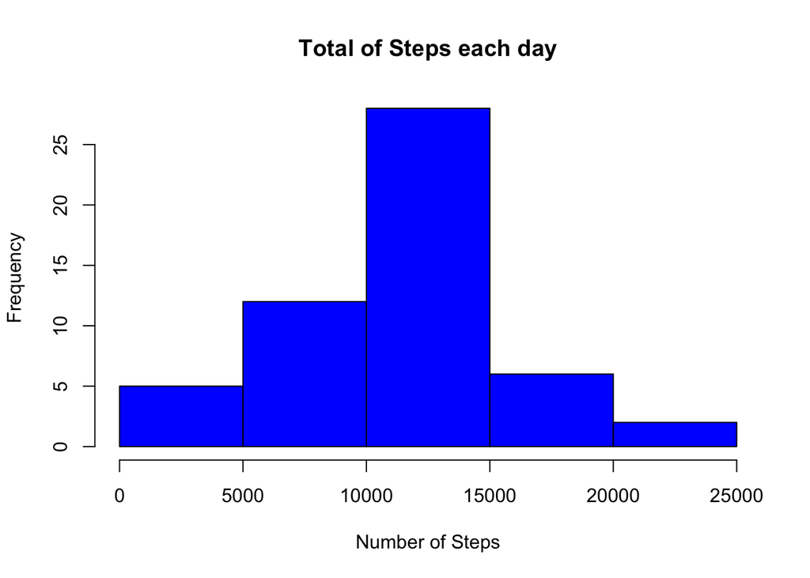

```r
hist(totalsteps$steps, xlab = "Number of Steps",
        main = "Total of Steps each day", col = "blue")
```

Calculate and report the mean and median of the total number of steps taken per day

```r
data.frame(mean = mean(totalsteps$steps), median = median(totalsteps$steps))
```

```
##       mean median
## 1 10766.19  10765
```

## What is the average daily activity pattern?

Calculate average steps for each interval for all days.

```r
IntervalSteps <-
        file1 %>% group_by(interval) %>% summarise(steps = mean(steps))
```

We create plot from data

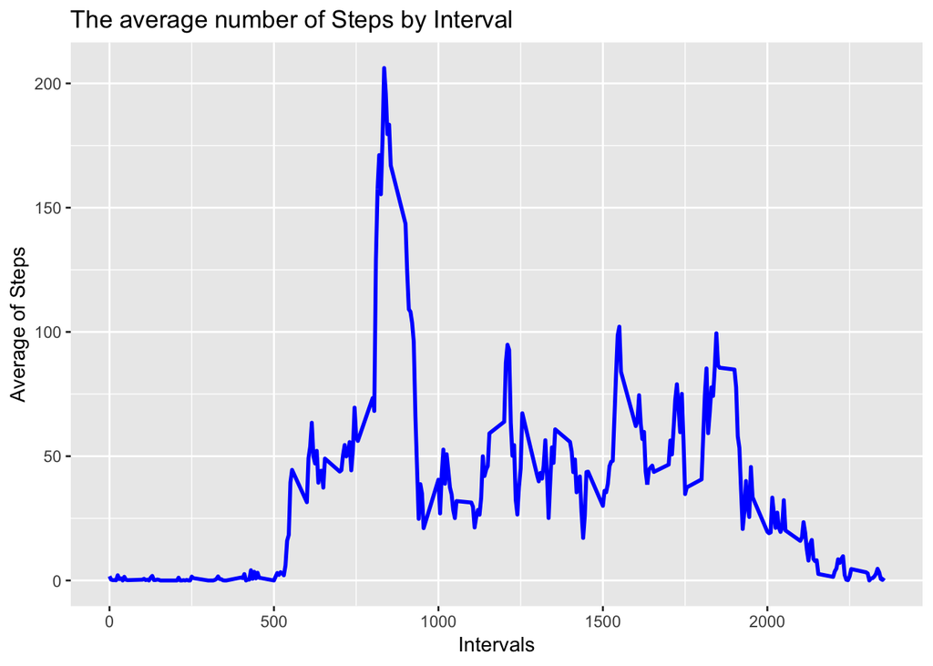

```r
ggplot(IntervalSteps, aes(x = interval, y = steps)) + geom_line(col = "blue", size = 1) + labs(x = "Intervals", y = "Average of Steps", title = "The average number of Steps by Interval")
```

Find interval with most average steps

```r
max(IntervalSteps$steps)
```

```
## [1] 206.1698
```

```r
IntervalSteps[which.max(IntervalSteps$steps),1]
```

```
## # A tibble: 1 x 1
##   interval
##      <int>
## 1      835
```

## Imputing missing values

The number of rows having steps is NA

```r
sum(is.na(file$steps))
```

```
## [1] 2304
```

Create new dataset, with it, NA is filed in

```r
fileinputed <- file %>%
        group_by(interval)%>%
        mutate(steps = replace(steps, is.na(steps), mean(steps, na.rm = TRUE)))
```

Calculate the total number of steps taken each day with the imputed data.

```r
datafull <- fileinputed %>%
        group_by(date) %>%
        summarise(steps = sum(steps))
```

Create plot from data

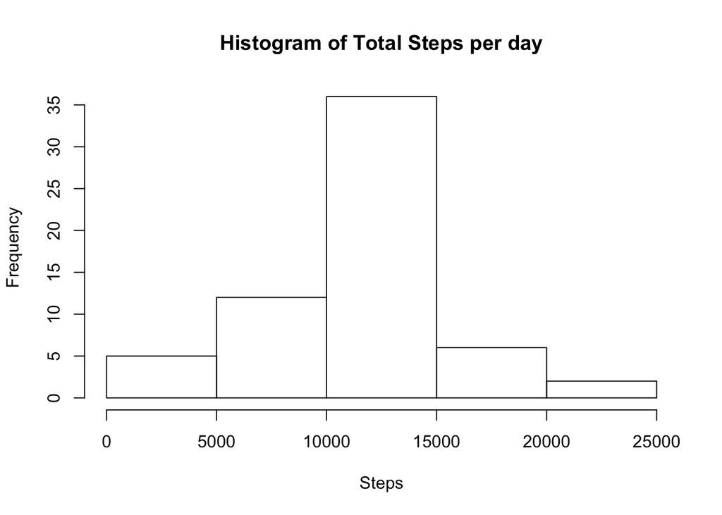

```r
hist(datafull$steps, xlab = "Steps", ylab = "Frequency", main = "Histogram of Total Steps per day")
```

```r
mean(datafull $steps)
```

```
## [1] 10766.19
```

```r
median(datafull$steps)
```

```
## [1] 10766.19
```

## Are there differences in activity patterns between weekdays and weekends?

Create new dataset, with it, seperating date to “Weekday” and “Weekend”

```r
fileinputed1 <- fileinputed %>%
        mutate(day = ifelse (weekdays(date) == "Sunday"| weekdays(date) == "Saturday", "weekend", "weekday"))
```

Turn type day into factor class

```r
fileinputed1$day <- as.factor(fileinputed1$day)
```

Caculate average steps group by day and interval

```r
fileavg <- fileinputed1 %>%
        group_by(day, interval) %>%
        summarise(steps = mean(steps))
```

Create plot from data

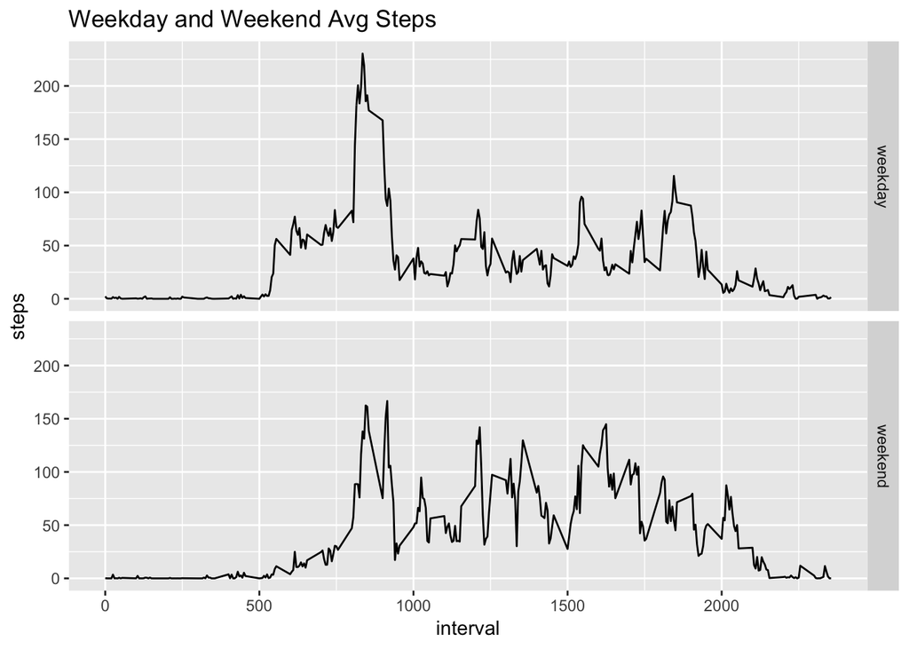

```r
ggplot(fileavg, aes(x = interval, y = steps)) + geom_line() + facet_grid(day ~ .) + labs(title = "Weekday and Weekend Avg Steps")
```

# Conclusion

There are some differences in average steps between Weekdays and Weekends. During weekdays, the person is more active at the start of the day and less active during the day. Meanwhile, during weekends, the person is less active at start of the day and more active throughout the day.

This is probably because the person is commuting to work in the morning and less active during work hours (sitting at desk). During weekends, the person does not have to prepare for work and therefore less active in the mornings, but more active during the day as the person is off from work.